# Introduction to R

Erik Gjesfjeld

March 26, 2019

### Welcome!

Welcome to the R workshop associated with the Big Data in Archaeology conference! The goal of this workshop is to introduce you to the R statistical environment as well as start to build research skills in the acquisition and cleaning of data, the analysis of radiocarbon data, and the social networks analysis. We are very lucky to have three leaders in the field of archaeological computing to help lead these sessions, they include Dr. Ben Marwick (University of Washington), Dr. Enrico Crema (University of Cambridge), and Dr. Matthew Peeples (Arizona State University). The schedule for the R workshop will be the following:

09:30 - 11:00 Introduction to R (Erik Gjesfjeld)  
11:30 - 13:00 Data Carpentry in R (Ben Marwick)  
14:00 - 15:30 Analysing Radiocarbon Dated (Enrico Crema)  
16:00 - 17:30 Social Network Analysis (Matt Peeples)

For those participants that already have a strong background in R, you are welcome to pick and choose the session you think are most relevant. For those of you that rarely use R or have never seen it before, no worries, we only ask that you try your best and to make sure and ask questions!

### What is R?

R is both a programming language and a software environment for statistical analysis, data management, and graphics. It is a powerful and flexible language and one of the most widely used statistical software packages in the world. If you are new to command-line interfaces the first few steps might feel daunting, but things will be easier as you familiarise yourself during this course. To start your R session click on the magnifying glass on the bottom left of your screen and start typing “R Statistical” then press enter on the first option available. This will open a console window with some lines detailing information regarding the version of R you are using, copyright, a disclaimer, and other things…

While many users of R commonly use this console to do their analysis, many users prefer to use an interface known as RStudio. To open R studio, go back to the magnifying glass or the start menu and search for “RStudio” and open the application. As you can see RStudio has a very different look than R. When first started there are three main windows, they include:

1. Console (left)
2. Workspace Environment / History (top right)
3. Output Files / Plots / Help (bottom right)

[figure not shown]

**The Console**: The console is the same window as what you saw when originally opening R. You will see the same information detailing the R version you are using (along with there odd names), copyright, disclaimer, etc. The console is the window in which R commands will be executed. The simplest way to do this is simply typing the commands into the console.

R is a so-called interpreted language, which just means that you can immediately see what happens when you execute your command. This is a convenient feature as you can try and test immediately your commands, in contrast to other programming languages that requires compiling (don’t worry if you don’t know what compiling means!). The > symbol on the console means that R is waiting for a command to be input by the user. Try now typing on your screen 2 + 2 and then press the Enter key on your keyboard. Pressing the Enter key will execute any line that you just typed. You should see something similar to below (without the hash-tags) on your screen:

```r
2 + 2
```

```
## [1] 4
```

Congratulations, you just executed your first R command and found out that 2 + 2 is equal to 4. R is a very powerful piece of software, but at its core it is just a calculator. You should have noticed that before your answer you have a [1]. We’ll come back to this later, for the time being consider this number indicating you that you have one value as an output to your expression.

Now try the following four calculations and see how they work:

```r
4-2
```

```
## [1] 2
```

```r
3*3
```

```
## [1] 9
```

```r
10/2
```

```
## [1] 5
```

```r
5^2
```

```
## [1] 25
```

You can easily tell from these commands that - is for subtractions, * for multiplications, / for divisions, and ^ for exponentiations. **Note** If not stated otherwise, the R functions you need to execute are within the grey shaded region of the handout. Sometimes results of the expression will be shown so you will be able to compare what you got on your screen and what you are supposed to get, but other times results will not be shown.

As for any mathematical expression, R follows the rules for the order of operations. So parenthesis first, then exponents (powers and roots), then multiply or divide, and then add or subtract (remember PEMDAS: Parenthesis first, Eponents, Multiplications and Divisions, and Adddition and Subtraction). The good news is that R knows this, so you just need to write everything down. For example:

```r
3^2+34/2-12
```

```
## [1] 14
```

is going to be different from

```r
(3^(2+34))/(2-12)
```

```
## [1] -1.500946e+16
```

The second result is written in the so-called E notation, you might have seen them on standard calculators. The letter e states for exponent, so 2e+5 means “2 multiplied by 105” (equivalent to 200000), whilst 3.4e-4 means “3.4 multiplied by 10−4 (equivalent to 0.00034)”. The trick is to consider the value after “e+” or “e-” as the number of zeroes before or after the value before the letter “e” (so 2e+5 is just 2 followed by 5 zeros and 3.4e-4 is four zeroes before 3.4).

**R Script**: Any larger sets of analysis you do will likely require many different commands. RStudio helps with this by providing a workspace to keep the commands and notes about the commands, in other words a R script. To open a new script, click on the icon in the top left of the window, it has a green plus sign on top of a blank sheet of paper and click on “R Script”.

As you will have noticed, we now have a new window in RStudio. This is where you can type in your commands and automatically send them to the console. Type the following into the script window:

```r
#Adding
2+2

#Subtracting
3-1
```

Adding a hashtag at the beginning of a line designates this line as comments, meaning the console will not execute them. This is very convinent for making notes and explaining to others what the function is doing (a very important part of creating reproducible reserach)!

In order to send the commands from the script to the console, you will need to place your curser on the line you want to execute, and then hit `control+enter`. The cursor will move sequentially to the next lines after sending each command to the console. It should look something like this:

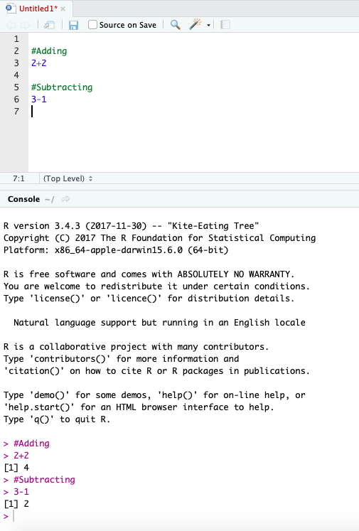

### Functions and Objects

I’m sure you are dying to know how to compute more complex expressions like square roots or logarithms. These require the use of functions, which are one of the key ingredients in R and is what gives R its incredible flexibility. R functions generally consist of a name followed by a pair of parenthesis within which you can place one or more arguments (these are also referred to as parameters). For example, square roots are computed as follows:

```r
sqrt(x=144)
```

```
## [1] 12
```

where the function `sqrt()` requires a single parameter called `x` the number to be evaluated. Notice that typing

```r
sqrt(144)
```

also works (output is not shown in the document). This is because R can guess which arguments you are referring to based on the order by which you insert your values. However if you type:

```r
sqrt(y=144)
```

You’ll get an error message. So it is always useful to know the name of the arguments you want to use. R has tens of thousands of functions (the number is growing) and memorising all of them (and their arguments) is just impossible. However, if you know the name of a function you can access its help documentation, which gives you many details (including examples) and most importantly will provide you with the name of your arguments. In order to visualise the help documentation type a question mark followed by the name of the function. In this case, type:

```r
?sqrt
```

which will open an html window with all the details you need.

#### Functions with more than one argument

Most functions require more than one arguments. For instance in order to calculate the logarithm of a number you would need to specify its base:

```r
log(x=32,base=2)
```

```
## [1] 5
```

In the example above we computed the logarithm of the number 32 with base 2. Logarithms (in case you don’t remember them) are just the inverse of exponentiation. That is the logarithm of 32 with base 2, is the exponent to which 2 (the base) should be raised in order to obtain 32 (you can check this by typing 2^5).

As mentioned earlier, the order of the arguments matter if you don’t specify their names. The following is fine:

```r
log(base=2,x=32)
```

```
## [1] 5
```

but

```r
log(2,32)
```

```
## [1] 0.2
```

will give you different answer.

It is worth noting that some arguments have defaults in case no values are supplied. In the case of log() the default argument for base is e, which is equal 2.71828… . Logarithms with this value as base are called natural logarithms.Thus in order to compute the natural logarithm of 32, you would just need to type:

```r
log(32)
```

```
## [1] 3.465736
```

#### Objects

As in any other programming language, R can store variables in the computer’s memory so it can be easily accessed anytime. R does this through particular data structures known as objects which are referred to through character symbols. Try the following expression:

```r
x = 1+4
```

You will notice that R did not return the result of your expression. Instead R “stored” the output of your expression in an object with the name x. Now if we just type

```r
x
```

```
## [1] 5
```

R returns its contents. This means that from now on (during this session of R) x will be treated as the number 5. For example:

```r
3+x
```

```
## [1] 8
```

will return 8. The object x will be equivalent to 5 until you assign a different value to it. So if you type:

```r
x = 12
```

and execute the same expression as before

```r
3 + x
```

```
## [1] 15
```

the result will be different. Notice that typing

```r
x = x + 5
x
```

```
## [1] 17
```

will update the value of x. This mean that you need to be sure to check time to time what your objects are! This can be easily done by examining the top-right window in your RStudio. You will see that the various objects that you created, and their updated values, so you should see something that shows your new x values as equaling 17.

#### Further bits

- R interprets the equal sign `=` as *assignment*. You can achieve the same result using the back arrow `<-` (a combination of the “less than” symbol and the minus). So the expression `x = 4+2` is identical to `x <- 4+2`. Some people prefer the back arrow for clarity but there are some circumstances where this might be confusing. For now just recall that sometimes I might use the back arrow and other times the equal symbol but that there are no difference between the two.
- You can give almost any names to R objects as long as they are not exclusively numbers or alphanumeric sequences starting from numbers (e.g. `1v` is not good but `v1` is OK). So `doughnuts = 4 + 2` is fine.

### Storing Data in R

#### Vectors

Vectors are one of the most common type of R object. They allow you to store a sequence of numbers in a single object. The simplest way to create a vector is to concatenate a set of values using the function `c()`. For example:

```r
x = c(23,45,12,5)
```

will assign the values 23,45,12, and 5 to the object named `x`. As for any other objects, you can check if this worked by typing the name of the object and then pressing the “enter” key on your keyboard. Now try the following:

```r
x[3]
```

```
## [1] 12
```

When a vector is followed by square brackets, the number within the brackets is interpreted by R as its index value. So in this case we asked R to print the third value of the vector `x`. The index itself can be an object or could even be a vector. For example:

```r
x = 2
y = c(12,45,12,6,90)
y[x]
```

```
[1] 45
```

Here we asked R to retrieve the second value from the vector named `y`. Here’s another example:

```r
x = c(1,4,5)
y = c(1,23,1,456,2,34)
y[x]
```

```
[1]   1 456   2
```

This time the vector `x` is contains 1, 4, and 5. So by typing `y[x]` we are asking R to return the 1st, 4th, and 5th values within the vector `y`. Now if you read carefully the help documentation of the function `sqrt()` you will notice that its states that the argument `x` should be “a numeric or complex *vector* or array” (emphasis added)“. This requirement is shared by many functions and operators, and allows for a particular algorithm to be *applied to each individual element of a vector*. This means that if I need to compute the square root of 8 different numbers all I need to do is to create a vector with these numbers place this as the argument for `sqrt()`. For example:

```r
x = c(23,12,56,34,123,67,1200,3211,23)
sqrt(x)
```

```
[1]  4.795832  3.464102  7.483315  5.830952 11.090537  8.185353 34.641016
[8] 56.665686  4.795832
```

Did I actually assigned 8 numbers in the vector `x`? We can check this with the function `length()`, which returns counts the number of items stored in a vector:

```r
length(x)
```

```
[1] 9
```

Turns out there were 9 values instead of 8. Now let’s try something useful using the few functions we learned so far through a very trivial case study.

*Vectors* are however just one of the many types of objects in R, and numbers are only one of the many kinds of variables R can handle. For example, if you wish to store strings of characters you will just need to use quotation marks for each set:

```r
x = "chimp"
x
```

```
[1] "chimp"
```

Notice that if you put a pair of parenthesis outside an assignment command you can simultaneously execute the command and display the content of the object. For example:

```r
(y = "bobcat")
```

```
[1] "bobcat"
```

As for numeric variable you can create vectors with strings of characters, and extract specific index items:

```r
x2 = c("seagull","kakapo","magpie")
x2[2]
```

```
[1] "kakapo"
```

Notice that everything within each set of quotation marks is read by R as a value. This means that you can store entire sentences as a single value:

```r
(x3 = "Erik made me write this")
```

```
[1] "Erik made me write this"
```

#### Data.frames

One of the most widely used type of R objects are *data.frames*. These are commonly used to store data tables and are structured as a collection of vectors with identical length and matching entries. The quickest way to understand what I mean by this is to make one from scratch. Suppose we are interested in the stature, weight, and biological sex of 5 students. We first create 4 vectors with the same length:

```r
name = c("John","Peter","Laura","Carlos","Julia")
sex =c("M","M","F","M","F")
height = c(172,185,166,169,158)
weight = c(75,88,55,73,51)
```

And then combine them using the `data.frame()` function (confusingly the function and the type of objects are called in the same way!):

```r
(df = data.frame(name,sex,height,weight))
```

```
    name sex height weight
1   John   M    172     75
2  Peter   M    185     88
3  Laura   F    166     55
4 Carlos   M    169     73
5  Julia   F    158     51
```

The *data.frame* `df` now contains all the vectors as a series of columns, with each row representing an unique individual. Thus, in this case we know that Carlos (4th row) is male, 169cm tall, and has a weight of 73kg. The key thing to remember is that variables associated to a given individual should be located on the same “place” (i.e. should have the same index value) in all vectors.

It is important to remember that R indexes data frames as rows and then columns `[row,column]`. So, if we wanted to know what data was in the fourth row we would type

```r
df[4,]
```

```
##     name sex height weight
## 4 Carlos   M    169     73
```

or in the fourth column

```r
df[,4]
```

```
## [1] 75 88 55 73 51
```

or the value in the second row and third column

```r
df[2,3]
```

```
## [1] 185
```

### Reading External Data

Manually creating *data.frames* in R is extremely time-consuming and error prone, so most people will use external programs to generate their tables and subsequently read them in R. This section will illustrate one of the most typical workflows where we read data generated in a spreadsheet.

#### Working Directory

Most R sessions will indeed entail reading or writing data files and so it is common practice to define a priori the folder where data are read from and/or output are stored in. This folder is called *working directory*. Whilst it is not crucial for carrying out most tasks, defining the *working directory* can simplify your commands. There are several ways for defining the *working directory*. On *Windows* machine, choose *File* and then *Change Dir …*, and when prompted choose your folder; on *Macs*, choose *Misc* and then *Change Working Directory*, and when prompted choose your folder. If you are using *RStudio*, then go to *Session*, then *Set Working Directory*, and then `setwd()` (raise your hand if you want to know how to use this). Once you’ve set your working directory you can check its file path (i.e. location) by typing the following command:

```r
getwd()
```

Notice that the brackets do not contain any arguments inside. Some R functions do not require any arguments, but you will still need to put the brackets, otherwise R will think that your are referring to an object. Another function that does not need any argument is `ls()`. Try using it: can you tell what it does?

Now create a folder in your desktop and name it **Intro_to_R** (or something similar), and set this as your *working directory* (either on the command line `setwd()` or through RStudio > Session > Set Working Directory)

#### Using an Excel spreadsheet to generate a table

Now let’s create a small spreadsheet and read this into R. Start *Microsoft Excel* (click on the windows icon on the bottom left of your screen and start typing “Office 2016 Excel” in order to search the program). You will see a grid-like structure, with rows identified by numbers, and columns by letters. Spreadsheets are like lined paper with columns and rows with spaces known as cells where you can write numbers or make calculations. Each cell can be identified by its row and columns, so for example the cell “B4” will be the one on the fourth row and the second column. Most spreadsheet programs allow you to store your data as you like, allowing you to decide how to organise visually your data. However this freedom comes with a cost, as non-conventional ways to structure your data will impede most other software packages (like R) to correctly read your data. The most widely used way to store your data is to consider each row as each one of your observations and your columns as different attributes (aka variables) associated to them.

Now let’s assume we are interested in making a spreadsheet recording some post-medieval cemetery data. We can think of a wide range of attributes, but for the time being we’ll consider only the following four: a unique identifier for each individual; estimated age at death, sex, and stature. We can designate each of the columns A to D to each of these variables, but it will be hard to remember which one is which. We will thus use the first row and type the name of these variables. This first row is known as the *header*.

- *Cell A1*: “ID”
- *Cell B1*: “age”
- *Cell C1*: “sex”
- *Cell D1*: “stature”

We are now ready to fill our spreadsheet with actual data. The figure below shows the screenshot of how your spreadsheet should look like.

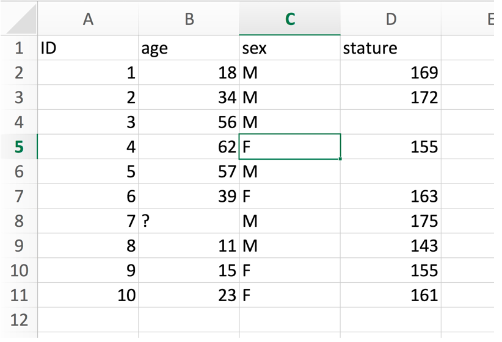

Once you have finished editing your spreadsheet (note: the blank spaces should be left as such!), click on *File* at the top-left of your screen, then select the option *Save* as and click on *Browse*. You should now see a screen where you are given the option to choose where to save your file. Select your working directory then type `intro_samples.csv` in *File name:* and click on the drop down arrow in the section *Save as type:*.This should list a large series of file formats, scroll down until you find *CSV (Comma delimited)* and click on it. Now press the *Save* button, and reply “Yes” to the question regarding the loss of some features. Reduce Excel to icon once finished (don’t close the session yet just in case!). If everything worked fine you should be able to see a new file in your working directory.

#### Reading CSV Files in R

We now need to ask R to read your data. This can be done using the following command:

```r
sampledata = read.csv("intro_samples.csv")
```

The function `read.csv()` reads CSV (an acronym for Comma Separated Values) files and requires as an argument the file name with its full path. However, in this case we stored our spreadsheet in the working directory so we just need to specify the name of the file. Notice that there are more direct ways to read excel spreadsheets in R but this requires some additional packages such as the [readxl](https://readxl.tidyverse.org/) package.

If everything worked fine you shouldn’t see any error message, and typing the name of you data.frame should show its contents:

```r
sampledata
```

```
   ID age sex stature
1   1  18   M     169
2   2  34   M     172
3   3  56   M      NA
4   4  62   F     155
5   5  57   M      NA
6   6  39   F     163
7   7   ?   M     175
8   8  11   M     143
9   9  15   F     155
10 10  23   F     161
```

```r
sampledata$stature
```

```
 [1] 169 172  NA 155  NA 163 175 143 155 161
```

Notice that some values are coded as `NA`. This is a specific format assigned to missing values (`NA` is for “Not Available”). Any blank cell value will be read by R as a `NA`. Notice that any calculation applied to an `NA` will return an `NA`. For example (you don’t need to write the line with the hash-tag):

```r
# convert from cm to inches
sampledata$stature * 0.393
```

```
 [1] 66.417 67.596     NA 60.915     NA 64.059 68.775 56.199 60.915 63.273
```

Now try the following command:

```r
sampledata$sex
```

```
 [1] M M M F M F M M F F
Levels: F M
```

This time R gives us a slightly different output. We have the contents of our vectors as before, but below this there is an additional line starting with “Levels”. This a particular type of variable type known as *Factors* that are designed to handle *categorical* (and *ordinal*) data. Recall from the lecture that categorical variables have different, mutually exclusive states known as *levels*. When reading external data, R assumes that any column containing characters should be read as *factors*, and automatically detects all unique cases to define its levels. Now type the following:

```r
sampledata$age
```

```
 [1] 18 34 56 62 57 39 ?  11 15 23
Levels: ? 11 15 18 23 34 39 56 57 62
```

The column `age` should be read as a numerical variable, but somehow R has read this as *factor*. What is going on? The reason why this happened is that we used the symbol `?` to define a missing value rather than leaving an empty cell. R doesn’t understand your convention, and hence reads the question marks as a character. Since numbers can be names of categorical variables, but characters cannot be numbers, R assumed that the column `age` was referring to a categorical variable. These kinds of mistakes are very common when making spreadsheets on you own, so be careful (another example is to refer to the same level using slightly different terms, e.g. “m”,“male”,“Male”, “M”; R will will treat them as different levels!). In this particular case there is actually a work-around: the function `read.csv` enables you to define what should be read as `NA`. So:

```r
sampledata = read.csv("./intro_samples.csv",na=c("","?"))
```

would treat both blank spaces (`""`) and question marks as NA.

### Querying your Data

Let’s read another dataset, this time containing some real data using a simplified version of the Chelsea Old Church cemetery data retrieved from [The Wellcome Osteological Research Database (WORD) of the Museum of London](http://archive.museumoflondon.org.uk/Centre-for-Human-Bioarchaeology/Database/). The data consist of two CSV files: `intro_individuals.csv` , which contains general information regarding each individual (e.g. estimated sex and age); and `intro_metrics.csv` which includes bone measurements (in mm). You can read these files directly from my GitHub repository using the very handy RCurl package.

#### Note on R Packages

One of the main reasons why R has become such a popular tool for data anaylsis is the wide variety of packages that are available to install. Broadly, R packages are free libraries of code and functions developed by users. These packages are stored at the R package repository known as CRAN and currently over 10,000 different packages are available. What type of research that you do, there is probably a packages that has been developed in order to help with data analysis.

Here, we are going to install a package called RCurl that allows us to download data from web servers, post forms, and a variety of other internet-based pages. To do this we first need to install the package, so type

```r
install.pacagkes("RCurl")
```

In RStudio, you can also install packages by clicking on the Tools menu, and navigating to the Install Packages option.

Once a packages is installed on your computer, it will remain there. However, everytime that you start R, you will need to load in the libraries that you need for analysis. You can do using the `library()` function.

```r
library(RCurl)
```

#### Getting the data

Once we have our library loaded in, we can use the prebuilt function `getURL` to download the csv file associated with a particular URL, in this case one from a GitHub repository. So, copy and paste the following commands into your R script or the console.

```r
individuals=read.csv(text=getURL("https://raw.githubusercontent.com/erikgjes/Introduction_to_R/master/intro_individuals.csv"),header=T)
metrics=read.csv(text=getURL("https://raw.githubusercontent.com/erikgjes/Introduction_to_R/master/intro_metrics.csv"),header=T)
```

You should now see two data frames appear in your RStudio environment pane. One of the individuals that has 198 observations (rows) and 6 variables (columns) and the other with 6889 observations and 4 variables. If you click on the data frame name, you can visualise the data in RStudio.

### Analysing our data

Both tables are quite large, so typing the name of the object and pressing the “Enter” key is not a wise idea (but feel free to try it if you want). Instead you can use the following function, which will show you just the first few rows (or the last few rows) of your data.frame:

```r
head(individuals)
```

```
  SITECODE DATE_S DATE_E ID    Sex       AgeEstimate
1    OCU00   1700   1850 18 FEMALE ADULT 36-45 YEARS
2    OCU00   1700   1850 19 FEMALE   ADULT >46 YEARS
3    OCU00   1700   1850 20   MALE ADULT 36-45 YEARS
4    OCU00   1700   1850 31 FEMALE ADULT 36-45 YEARS
5    OCU00   1821     NA 35   MALE   ADULT >46 YEARS
6    OCU00   1700   1850 39 FEMALE ADULT 36-45 YEARS
```

```r
head(metrics)
```

```
  ID value   group                           metric
1 18  45.3 Cranial            ext-L External Length
2 18  63.1 Cranial ext-B External Breadth (ecm-ecm)
3 18 180.0 Cranial                 L Maximum Length
4 18 137.0 Cranial                B Maximum Breadth
5 18 138.0 Cranial         H' Basi-Bregmatic Height
6 18 105.0 Cranial             LB Basi-Nasal Length
```

```r
tail(individuals)
```

```
    SITECODE DATE_S DATE_E   ID            Sex         AgeEstimate
193    OCU00   1700   1850 1157           MALE     ADULT >46 YEARS
194    OCU00   1700   1850 1164  UNSEXED CHILD SUB-ADULT 1-5 YEARS
195    OCU00   1700   1850 1169 UNDETERMINABLE  UNCLASSIFIED ADULT
196    OCU00   1700   1850 1175        FEMALE?   ADULT 36-45 YEARS
197    OCU00   1700   1850 1611  UNSEXED CHILD SUB-ADULT PERINATAL
198    OCU00     NA     NA 2321  UNSEXED CHILD SUB-ADULT PERINATAL
```

This gives us a broad idea about the type of information stored in each data.frame but nothing more. One of simplest queries that you might want to carry out is to check how many rows are present in a given data.frame. This can be achieved with the following command:

```r
nrow(individuals)
```

```
[1] 198
```

```r
nrow(metrics)
```

```
[1] 6889
```

#### Counting Cases

Suppose now we want to count how many individuals were male and how many were female. The function `table()` can give us the answer:

```r
table(individuals$Sex)
```

```
        FEMALE        FEMALE?   INTERMEDIATE           MALE          MALE?
            59             15              5             64             14
UNDETERMINABLE  UNSEXED CHILD
             8             33
```

The function reads as argument one (or more, see below) vector of factor variables, and computes the number of cases for each level. Try doing the same with the column *AgeEstimate* on your own.

Now, suppose we want to calculate the number cases for unique combination of both categorical variables *Sex* and *AgeEstimate*, e.g. we want to know how many individuals were `FEMALE` and with an *AgeEstimate* equal to `ADULT >46 YEARS`. To do so we just need to specify both vectors in our `table()` function:

```r
table(individuals$Sex,individuals$AgeEstimate)
```

```
                 ADULT >46 YEARS ADULT 18-25 YEARS ADULT 26-35 YEARS
  FEMALE                      32                 8                 5
  FEMALE?                      4                 1                 2
  INTERMEDIATE                 1                 0                 1
  MALE                        30                 5                 8
  MALE?                        5                 0                 1
  UNDETERMINABLE               0                 0                 0
  UNSEXED CHILD                0                 0                 0

                 ADULT 36-45 YEARS SUB-ADULT 1-5 YEARS
  FEMALE                        11                   0
  FEMALE?                        6                   0
  INTERMEDIATE                   3                   0
  MALE                          21                   0
  MALE?                          5                   0
  UNDETERMINABLE                 0                   0
  UNSEXED CHILD                  0                  13

                 SUB-ADULT 1-6 MONTHS SUB-ADULT 12-17 YEARS
  FEMALE                            0                     0
  FEMALE?                           0                     0
  INTERMEDIATE                      0                     0
  MALE                              0                     0
  MALE?                             0                     0
  UNDETERMINABLE                    0                     0
  UNSEXED CHILD                     5                     3

                 SUB-ADULT 6-11 YEARS SUB-ADULT 7-11 MONTHS
  FEMALE                            0                     0
  FEMALE?                           0                     0
  INTERMEDIATE                      0                     0
  MALE                              0                     0
  MALE?                             0                     0
  UNDETERMINABLE                    0                     0
  UNSEXED CHILD                     5                     1

                 SUB-ADULT PERINATAL UNCLASSIFIED ADULT
  FEMALE                           0                  3
  FEMALE?                          0                  2
  INTERMEDIATE                     0                  0
  MALE                             0                  0
  MALE?                            0                  3
  UNDETERMINABLE                   0                  8
  UNSEXED CHILD                    3                  0

                 UNCLASSIFIED SUB-ADULT
  FEMALE                              0
  FEMALE?                             0
  INTERMEDIATE                        0
  MALE                                0
  MALE?                               0
  UNDETERMINABLE                      0
  UNSEXED CHILD                       3
```

The resulting table is known as a *crosstabulation*. Each cell records the joint frequencies for specific combination of levels from the two categorical variables.

#### Creating Subsets Using Boolean Logic

Now let’s examine the *metrics* data.frame. Each row in this case represents a different measurement. The column named `ID` refers to the individual to which a specific bone is associated (notice this is matching with the column ID in the *individuals* data.frame), the column `value` stores the actual measurement in mm, and the column `metric` gives us detail on the type of bone and measurement (e.g. `FeL1 R` is the maximum length of the right Femur). Now suppose we are just interested in one kind of measurement, e.g. `FeL1 R`. Rather than handling the entire data.frame we could make a subset of cases where values of the column `metric` are equal to `FeL1 R`.

To achieve this we can use a function called `subset()`. This requires two arguments: 1) the name of the *data.frame* from which we want to generate our subset; and 2) a *Boolean condition*. Recall from the lecture that the latter enable us to specify conditions where each observation is either `TRUE` or `FALSE`; the `subset()` function will return all cases where the condition is `TRUE`. R handles a variety of Boolean operators — this practical will introduce you to the most common ones.

#### Equality

Let’s start with the most basic operator. Recall we want all cases where `metric` is equal to `FeL1 R`. To do so just type:

```r
cond1 = subset(metrics, metric=="FeL1 R")
head(cond1) #show just the first few lines
```

```
    ID value        group metric
31  18   415 Post-Cranial FeL1 R
91  19   433 Post-Cranial FeL1 R
161 20   469 Post-Cranial FeL1 R
243 31   424 Post-Cranial FeL1 R
381 39   397 Post-Cranial FeL1 R
436 43   444 Post-Cranial FeL1 R
```

```r
subset(metrics, value==100)
```

```
       ID value        group                  metric
10     18   100      Cranial        S3 Occipital Arc
838   147   100 Post-Cranial                     SaL
2035  339   100   Mandibular     M< Mandibular Angle
2953  485   100      Cranial    LB Basi-Nasal Length
3086  496   100      Cranial    LB Basi-Nasal Length
3088  496   100      Cranial GL Basi-Alveolar Length
3095  496   100      Cranial     S3' Occipital Chord
3109  496   100   Mandibular       ML Maximum Length
3172  502   100 Post-Cranial                   FeC L
3791  544   100      Cranial     S3' Occipital Chord
4069  583   100      Cranial    LB Basi-Nasal Length
4200  593   100      Cranial GL Basi-Alveolar Length
4696  681   100      Cranial    LB Basi-Nasal Length
5201  754   100   Mandibular       ML Maximum Length
5280  759   100 Post-Cranial                   FeC L
5605  812   100   Mandibular       ML Maximum Length
6495 1021   100   Mandibular   GoGo Bigonial Breadth
6691 1068   100 Post-Cranial                     SaB
```

#### Greater/Lesser

The most common kind of Boolean operator specific to numerical values are *greater than* (`>`), *equal or greater than* (`>=`), *lesser than* (`<`), and *equal or lesser than* (`<=`). Here are some examples:

```r
subset(cond1, value>480)
```

```
       ID value        group metric
841   147   490 Post-Cranial FeL1 R
6296  994   484 Post-Cranial FeL1 R
6503 1021   485 Post-Cranial FeL1 R
6841 1169   486 Post-Cranial FeL1 R
```

```r
subset(cond1, value>=480)
```

```
       ID value        group metric
841   147   490 Post-Cranial FeL1 R
3489  525   480 Post-Cranial FeL1 R
4394  635   480 Post-Cranial FeL1 R
6296  994   484 Post-Cranial FeL1 R
6503 1021   485 Post-Cranial FeL1 R
6841 1169   486 Post-Cranial FeL1 R
```

```r
#compute percentage of individuals with the Right femur Length shorter than 450:
cond2=subset(cond1, value < 450)
nrow(cond2) / nrow(cond1) *100
```

```
[1] 72.72727
```

#### Combining Multiple Conditions at Once with **AND**

In many situations you might want to apply multiple conditions. For example, the data.frame `cond2` is the result of two sets of conditions, one where we asked R to subset all cases where `metric` is equal to `FeL1 R` (which produced the object `cond1`), and one where we asked `value` to be smaller than 450. This can be achieved by using `subset()` twice (as we did), or by using the `AND` operator (the `&` sign in R) as follows:

```r
cond3 = subset(metrics, metric=="FeL1 R" & value < 450)
```

#### the **OR** operator

Suppose you are just interested in the maximum femur length and the side doesn’t really matter. To achieve this you would need to make two subsets, one for the right femur and one for the left:

```r
right = subset(metrics, metric=="FeL1 R")
left = subset(metrics, metric=="FeL1 L")
```

and then combine these using the `rbind.data.frame()` function:

```r
rightleft = rbind.data.frame(right,left)
```

A much quicker way to achieve the same result is to use the *OR* operator (the `|` sign in R) as follows:

```r
rightleft2 = subset(metrics, metric=="FeL1 R"|metric=="FeL1 L")
```

#### Unique Cases

Both approaches above return a data.frame with right and left measurements. Suppose now we want to find out how many individuals have at least one of the two measurements. The `nrow()` counts the total number of rows, so individuals with both femurs will be counted twice. Dividing this number by two however assumes that all individuals have both femurs, which might not necessarily be the case! One handy function in this case is `unique()`, which returns a vector (or a data.frame) without duplicates. Here’s an trivial example of how it works:

```r
x = c(1,1,1,2,3)
unique(x)
```

```
[1] 1 2 3
```

We can apply the same principle retrieving the unique cases of the individual IDs in our subset, and then use the `length()` function to calculate how many cases we have:

```r
uniqueIDs = unique(rightleft2$ID)
length(uniqueIDs)
```

```
[1] 90
```

We have 90 individuals having at least one of the two femurs.

#### The **IN** Operator

Let’s say that now we want to find out how many female individuals have a left femur length greater than 450mm. To do so we need to `subset()` the object *metrics*, using information stored in the data.frame *individuals*. There are many ways to do this, one of them involve the use of the *IN* operator `%in%`. This checks whether each member of the vector on the left is within the set of values defined by the second vector. This sounds more complicated than what it is. Here’s an example with some strings of characters:

```r
thebeatles = c("john","paul","ringo","george")
somenames = c("simon","mick","george","john","sue")
somenames%in%thebeatles
```

```
[1] FALSE FALSE  TRUE  TRUE FALSE
```

The last line of the code above returns a sequence of TRUE and FALSE. The 3rd and the 4th values, corresponding to “george” and “john” in the vector `somenames` are TRUE, as these names are in the vector `thebeatles`. The others are nor present so they are returned as FALSE.

Let’s use this operator to achieve our objective. We can start by making a subset of all female individuals:

```r
female = subset(individuals,Sex=="FEMALE"|Sex=="FEMALE?")
```

and then use the AND operator to apply all our conditions:

```r
subset(metrics,ID%in%female$ID & metric=="FeL1 L" & value > 450 )
```

```
      ID value        group metric
4927 716   459 Post-Cranial FeL1 L
5216 754   451 Post-Cranial FeL1 L
5386 790   466 Post-Cranial FeL1 L
```

#### Nested Operations

Once you get used to boolean operators you can make fairly complex queries by combining them using round brackets. The example below returns all femur lengths (either right or left) between 450 and 460 mm that are from individuals with an age estimate between 18 and 25:

```r
young = subset(individuals,AgeEstimate=="ADULT 18-25 YEARS")
cond6 = subset(metrics, ID%in%young$ID & (metric=="FeL1 R" | metric=="FeL1 L") & value > 450 & value < 460)
```

### R as a database

Another way to carry out some of the queries we executed above is to combine together the *individuals* and the *metrics* data.frame using the common field “ID”. Here is the command to do that:

```r
combined = merge(x=individuals, y=metrics,by.x="ID",by.y="ID")
head(combined)
```

```
  ID SITECODE DATE_S DATE_E    Sex       AgeEstimate value   group
1 18    OCU00   1700   1850 FEMALE ADULT 36-45 YEARS  45.3 Cranial
2 18    OCU00   1700   1850 FEMALE ADULT 36-45 YEARS  63.1 Cranial
3 18    OCU00   1700   1850 FEMALE ADULT 36-45 YEARS 180.0 Cranial
4 18    OCU00   1700   1850 FEMALE ADULT 36-45 YEARS 137.0 Cranial
5 18    OCU00   1700   1850 FEMALE ADULT 36-45 YEARS 138.0 Cranial
6 18    OCU00   1700   1850 FEMALE ADULT 36-45 YEARS 105.0 Cranial
                            metric
1            ext-L External Length
2 ext-B External Breadth (ecm-ecm)
3                 L Maximum Length
4                B Maximum Breadth
5         H' Basi-Bregmatic Height
6             LB Basi-Nasal Length
```

The new data.frame `combined` contains now information from both tables, i.e. instead of having just the ID of the individual associated to each metrics we have also their characteristics (e.g. AgeEstimate and Sex). This means that the question “how many female individuals have a left femur length greater than 450mm” can now be answered with the following command:

```r
nrow(subset(combined,(Sex=="FEMALE"|Sex=="FEMALE?")&metric=="FeL1 L"&value>450))
```

```
[1] 3
```

instead of:

```r
female = subset(individuals,Sex=="FEMALE"|Sex=="FEMALE?")
nrow(subset(metrics,ID%in%female$ID & metric=="FeL1 L" & value > 450 ))
```

```
[1] 3
```

Some of you might have noticed that the `merge()` function resembles the `JOIN TABLE` command in SQL. The example above in fact is an instance of the so-called *Inner Join*, where the output considers only cases where individuals are present in both tables. There are many other ways to combine datasets. The example below uses two simple data.frames which will help you understand how each command works:

```r
(df1 = data.frame(x1=c("A","B","C"),x2=c(1,2,3)))
```

```
  x1 x2
1  A  1
2  B  2
3  C  3
```

```r
(df2 = data.frame(x1=c("A","B","D"),x3=c("red","blue","red")))
```

```
  x1   x3
1  A  red
2  B blue
3  D  red
```

#### Left Join

```r
merge(x=df1, y=df2,by.x="x1",by.y="x1",all.x=TRUE)
```

```
  x1 x2   x3
1  A  1  red
2  B  2 blue
3  C  3 <NA>
```

#### Right Join

```r
merge(x=df1, y=df2,by.x="x1",by.y="x1",all.y=TRUE)
```

```
  x1 x2   x3
1  A  1  red
2  B  2 blue
3  D NA  red
```

#### Full Join

```r
merge(x=df1, y=df2,by.x="x1",by.y="x1",all.x=TRUE,all.y=TRUE)
```

```
  x1 x2   x3
1  A  1  red
2  B  2 blue
3  C  3 <NA>
4  D NA  red
```

#### Inner Join

```r
merge(x=df1, y=df2,by.x="x1",by.y="x1",all=FALSE)
```

```
  x1 x2   x3
1  A  1  red
2  B  2 blue
```

If you foresee a lot of complex data handling in R, you might consider learning to use the [dplyr](https://dplyr.tidyverse.org/) and the [tidyr](https://tidyr.tidyverse.org/) packages. This is what Ben Marwick will cover in the next session! The former allows you to manipulate and query your data, while the latter provides a power mean to reshape your data.frame (especially when they are not neatly organised in column=variables, rows=observation, and cells=values)

### Saving your session

Whew, You’ve reached the end of our first session! In order to save the objects you created type:

```r
save.image("intro_to_R.RData")
```

This will create an R image containing all the objects you created during this session. To save a log of all the commands you used, type instead:

```r
savehistory("intro_to_R.Rhistory")
```

Of course you should also save the R script that you used to type out our commands.

#### Note for Beginners

There is no doubt that learning R can seem very dauting at first, this is normal. Just like any language, with a little practice you start to understand the structure of indexing, functions, and arguments. You will never possibly remember all the different functions and commands but over time you will be able to better read the help files and gain comfortability.